# Tiesinė kalibracija

Tiesinės regresinės analizės pavyzdys

2022-12-28

# 1 Užduotis

Atliktas tyrimas, kurio metu buvo paruošta žinoma tirpalo koncentracija nuo 3,5 mg/ml iki 70,0 mg/ml. Išmatuotas šių tirpalų optinis tankis ties 660 nm spinduliuote, o duomenys pateikti byloje „`kalibravimui_d1.xlsx`“. Vėliau buvo atliktas eksperimentas, kurio metu buvo susintetinta ta pati medžiaga, o jos tirpalo optinis tankis mėgintuvėlyje buvo 0,334. Laikydami, kad optinis tankis kito tik dėl tyrėjus dominančios medžiagos, įvertinkite, kokia medžiagos koncentracija buvo tirpale?

# 2 Sprendimas

## 2.1 Duomenų įkėlimas ir peržiūra

```r
excel_sheets("duomenys/kalibravimui_d1.xlsx")
```

```r
duomenys_d1 <- read_excel("duomenys/kalibravimui_d1.xlsx", sheet = "duomenys")
```

Nuskaitytus duomenis reikia peržiūrėti (atlikti skaitines ir grafines suvestines, kad žinotume, ką turime, ir kad viskas su duomenimis tvarkoje).

Duomenų peržiūra ir suvestinė:

```r
View(duomenys_d1)
```

```r
glimpse(duomenys_d1)
```

```
## Rows: 20
## Columns: 2
## $ koncentracija <dbl> 3.5, 7.0, 10.5, 14.0, 17.5, 21.0, 24.5, 28.0, 31.5, 35.0…
## $ OD            <dbl> 0.03829897, 0.11035153, 0.10391472, 0.20783131, 0.251204…
```

```r
summary(duomenys_d1)
```

```
##  koncentracija         OD
##  Min.   : 3.50   Min.   :0.0383
##  1st Qu.:20.12   1st Qu.:0.2904
##  Median :36.75   Median :0.5027
##  Mean   :36.75   Mean   :0.5191
##  3rd Qu.:53.38   3rd Qu.:0.7437
##  Max.   :70.00   Max.   :0.9769
```

Grafikas - sklaidos diagrama.

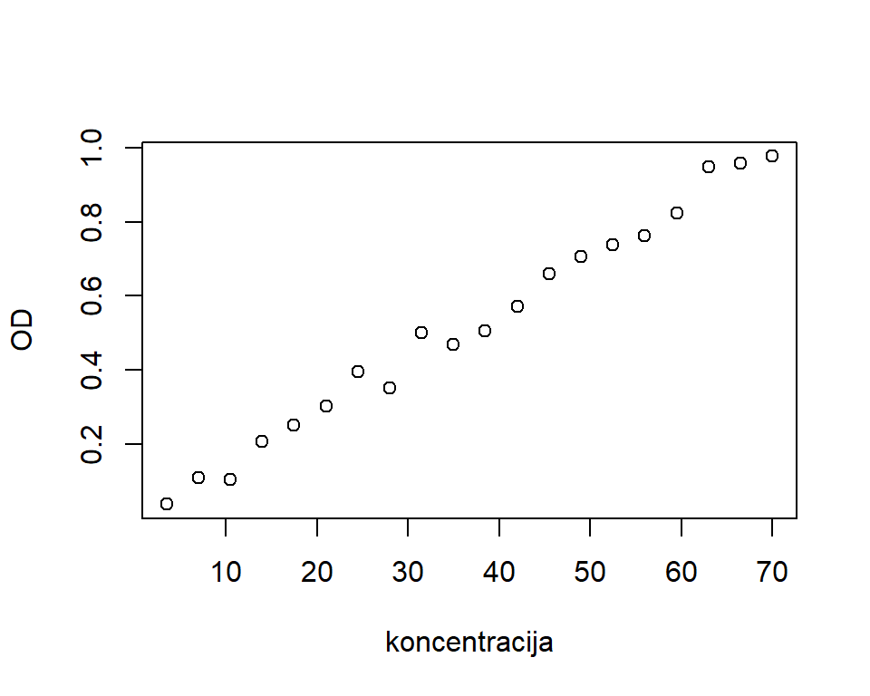

```r
# Kodas naudojamas taip: mano_Y ~ mano_X, data = mano_duomenys
plot(OD ~ koncentracija, data = duomenys_d1)
```

## 2.2 Modeliavimas

### 2.2.1 Modelio sudarymas

Sudarome tokios formos lygtį: $Y = a + bX$, t. y., $OD = a + b \times koncentracija$.

```r
modelis1 <- lm(OD ~ koncentracija, data = duomenys_d1)
```

### 2.2.2 Modelio braižymas

Tinka tik tam atvejui, kai ryšys yra teigiamas.

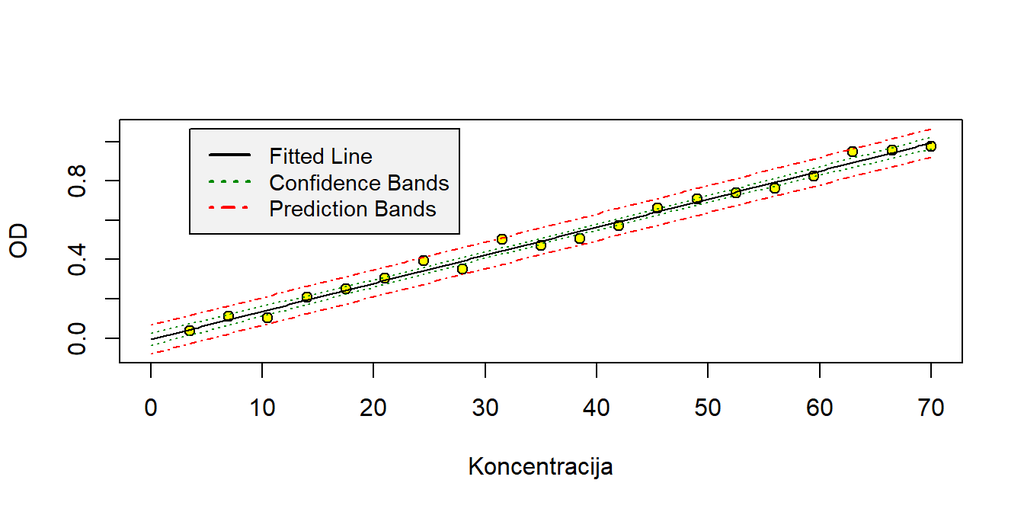

```r
# Kalibracijos kreivė:
chemCal::calplot(modelis1, xlab = "Koncentracija", ylab = "OD")
```

### 2.2.3 Modelio parametrų peržiūra

1. Ar yra ryšys tarp $Y$ ir bent vieno $X$?
2. Kaip gerai modelis paaiškina duomenų kitimą?
3. Nustatome koeficientus ir į lygtį įrašome apvalindami tuo pačiu tikslumu.

```r
summary(modelis1)
```

```
##
## Call:
## lm(formula = OD ~ koncentracija, data = duomenys_d1)
##
## Residuals:
##       Min        1Q    Median        3Q       Max
## -0.042972 -0.022962  0.000342  0.014739  0.056532
##
## Coefficients:
##                 Estimate Std. Error t value Pr(>|t|)
## (Intercept)   -0.0053379  0.0146288  -0.365    0.719
## koncentracija  0.0142699  0.0003489  40.898   <2e-16 ***
## ---
## Signif. codes:  0 '***' 0.001 '**' 0.01 '*' 0.05 '.' 0.1 ' ' 1
##
## Residual standard error: 0.03149 on 18 degrees of freedom
## Multiple R-squared:  0.9894, Adjusted R-squared:  0.9888
## F-statistic:  1673 on 1 and 18 DF,  p-value: < 2.2e-16
```

Tad gauname $OD = -0{,}005 + 0{,}014 × koncentracija$, $R^2 = 0{,}989$.

### 2.2.4 Prielaidų tikrinimas

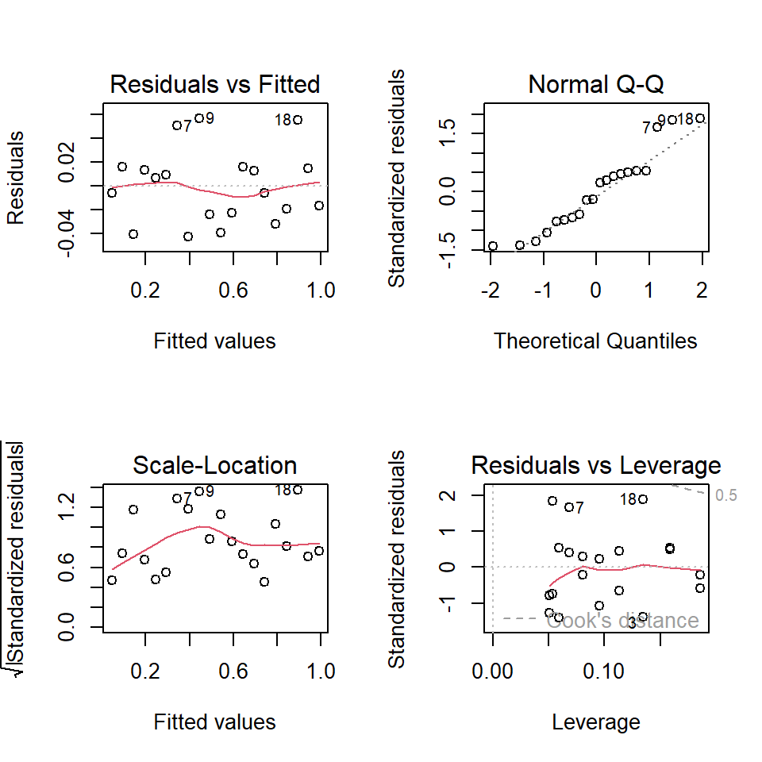

```r
op <- par(mfrow = c(2, 2))
plot(modelis1)
```

```r
par(op)
```

**Papildoma**

```r
paklaidos <- residuals(modelis1)
```

**Ar paklaidų vidurkis lygus nuliui?**

```r
t.test(paklaidos)
```

```
##
##  One Sample t-test
##
## data:  paklaidos
## t = -6.2781e-18, df = 19, p-value = 1
## alternative hypothesis: true mean is not equal to 0
## 95 percent confidence interval:
##  -0.01434537  0.01434537
## sample estimates:
##     mean of x
## -4.302927e-20
```

**Ar paklaidos skirstosi *normaliai*?**

```r
shapiro.test(paklaidos)
```

```
##
##  Shapiro-Wilk normality test
##
## data:  paklaidos
## W = 0.9291, p-value = 0.1484
```

**Ar taškų sklaida yra vienoda ties kiekviena $X$ reikšme?**

```r
lmtest::bptest(modelis1)
```

```
##
##  studentized Breusch-Pagan test
##
## data:  modelis1
## BP = 0.014074, df = 1, p-value = 0.9056
```

**Ar yra išskirčių?**

```r
car::outlierTest(modelis1)
```

```
## No Studentized residuals with Bonferroni p < 0.05
## Largest |rstudent|:
##    rstudent unadjusted p-value Bonferroni p
## 18 2.048817           0.056242           NA
```

### 2.2.5 LOD ir LOQ

**Papildoma**

```r
lod_rez <- chemCal::lod(modelis1)
lod_rez
```

```
## $koncentracija
## [1] 8.321946
##
## $OD
## [1] 0.1134151
```

```r
loq_rez <- chemCal::loq(modelis1)
loq_rez
```

```
## $koncentracija
## [1] 14.65396
##
## $OD
## [1] 0.203772
```

### 2.2.6 Modelio taikymas

```r
# Vienu metu gali būti nurodoma tik viena nauja reikšmė.
nauja_reiksme <- 0.334

rez <- chemCal::inverse.predict(modelis1, newdata = nauja_reiksme)
# Atvaizdavimas duomenų lentelės pavidalu.
rez %>% map(scales::number, accuracy = 0.1) %>% unlist() %>% t() %>% as_tibble()
```

```
## # A tibble: 1 × 5
##   Prediction `Standard Error` Confidence `Confidence Limits1` Confidence Limit…¹
##   <chr>      <chr>            <chr>      <chr>                <chr>
## 1 23.8       2.3              4.8        19.0                 28.6
## # … with abbreviated variable name ¹`Confidence Limits2`
```

# 3 Atsakymas

Sudarytas tiesinės regresijos modelis $OD = -0{,}005 + 0{,}014 × koncentracija$, $R^2 = 0{,}99$. Modeliui keliamos prielaidos buvo tenkinamos. Pagal šį modelį nustatyta, kad mėgintuvėlyje, kuriame esančio tirpalo optinis tankis yra 0,334, medžiagos koncentracija buvo 23,8 (95% PI 19,0–28,6) mg/ml. Rezultatai grafiškai atvaizduoti pav. 1.

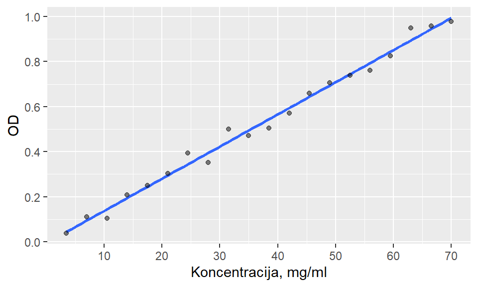

```r
caption <- paste0("**Pav 1.** Sklaidos diagrama su regresijos tiese (mėlyna). ",
  "Paklaidų ribos žymi koncentracijos naujajame mėginyje 95% pasikliautinąjį ",
  "intervalą (PI), šviesiai raudonos punktyrinės linijos – medžiagos aptikimo ",
  "ribą (LOD).  ")

ggplot(duomenys_d1, aes(x = koncentracija, y = OD)) +

  # Duomenys ir modelis
  geom_smooth(method = lm, formula = y ~ x, se = FALSE) +
  geom_point(alpha = 0.5) +

  # Grafiko apipavidalinimas
  scale_x_continuous(n.breaks = 7) +
  scale_y_continuous(n.breaks = 6) +
  labs(x = "Koncentracija, mg/ml")
```

**Grafikas su išplėstiniais rezultatais**

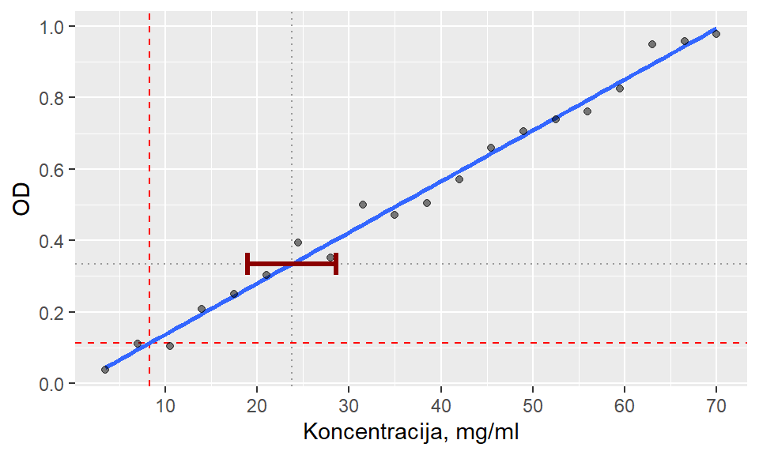

**Pav 1.** Sklaidos diagrama su regresijos tiese (mėlyna). Paklaidų ribos žymi koncentracijos naujajame mėginyje 95% pasikliautinąjį intervalą (PI), šviesiai raudonos punktyrinės linijos – medžiagos aptikimo ribą (LOD).

```r
caption <- paste0("**Pav 1.** Sklaidos diagrama su regresijos tiese (mėlyna). ",
  "Paklaidų ribos žymi koncentracijos naujajame mėginyje 95% pasikliautinąjį ",
  "intervalą (PI), šviesiai raudonos punktyrinės linijos – medžiagos aptikimo ",
  "ribą (LOD).  ")

ggplot(duomenys_d1, aes(x = koncentracija, y = OD)) +
  # Aptikimo riba (LOD)
  geom_vline(xintercept = lod_rez[[1]], color = "red", linetype = "dashed") +
  geom_hline(yintercept = lod_rez[[2]], color = "red", linetype = "dashed") +

  # Duomenys ir modelis
  geom_smooth(method = lm, formula = y ~ x, se = FALSE) +
  geom_point(alpha = 0.5) +

  # Naujos koncentracijos žymėjimas
  geom_vline(xintercept = rez$Prediction, color = "grey60", linetype = "dotted") +
  geom_hline(yintercept = nauja_reiksme,  color = "grey60", linetype = "dotted") +
  geom_errorbarh(
    aes(
      y = nauja_reiksme,
      xmin = min(rez$`Confidence Limits`),
      xmax = max(rez$`Confidence Limits`)
    ),
    color = "darkred", height = .06, linewidth = 1.1
  ) +

  # Grafiko apipavidalinimas
  scale_x_continuous(n.breaks = 7) +
  scale_y_continuous(n.breaks = 6) +
  labs(x = "Koncentracija, mg/ml")
```